# scRNA-seq Analysis with Seurat

Ali Yavuz Cakir

2024-09-23

## Introduction

In this workshop, we will go through a basic workflow for analyzing single-cell RNA-sequencing data using the Seurat package. We will start by exploring the Seurat object, which is the backbone for storing and analyzing data.

## Loading Required Libraries

```r
# Install Seurat if not installed
remotes::install_github("satijalab/seurat", "seurat5", quiet = TRUE)
remotes::install_github("satijalab/seurat-data", "seurat5", quiet = TRUE)


# Load Seurat library
library(Seurat)
library(SeuratData)
```

## Loading the Dataset

We will use the `pbmcsca` dataset. This public dataset includes single-cell RNA-seq data of human peripheral blood mononuclear cells (PBMCs) using multiple sequencing platforms. Only data that *passed quality control* are included in the `pbmcsca` dataset.

```r
InstallData("pbmcsca")
data("pbmcsca")
pbmcsca <- UpdateSeuratObject(pbmcsca)
```

```
## Validating object structure
```

```
## Updating object slots
```

```
## Ensuring keys are in the proper structure
```

```
## Ensuring keys are in the proper structure
```

```
## Ensuring feature names don't have underscores or pipes
```

```
## Updating slots in RNA
```

```
## Validating object structure for Assay 'RNA'
```

```
## Object representation is consistent with the most current Seurat version
```

```r
table(pbmcsca$Method)
```

```
##
##   10x Chromium (v2) 10x Chromium (v2) A 10x Chromium (v2) B   10x Chromium (v3)
##                3362                3222                3222                3222
##            CEL-Seq2            Drop-seq             inDrops            Seq-Well
##                 526                6584                6584                3773
##          Smart-seq2
##                 526
```

```r
# Load PBMC data by 10x Chromium versions
pbmc_10x_v2 <- pbmcsca[, pbmcsca$Method == "10x Chromium (v2)"]
pbmc_10x_v3 <- pbmcsca[, pbmcsca$Method == "10x Chromium (v3)"]

# Combine both v2 and v3 datasets
pbmc_combo <- pbmcsca[, pbmcsca$Method %in% c("10x Chromium (v2)", "10x Chromium (v3)")]

# Display basic information about the object
pbmc_10x_v2
```

```
## An object of class Seurat
## 33694 features across 3362 samples within 1 assay
## Active assay: RNA (33694 features, 0 variable features)
##  2 layers present: counts, data
```

```r
pbmc_10x_v3
```

```
## An object of class Seurat
## 33694 features across 3222 samples within 1 assay
## Active assay: RNA (33694 features, 0 variable features)
##  2 layers present: counts, data
```

```r
pbmc_combo
```

```
## An object of class Seurat
## 33694 features across 6584 samples within 1 assay
## Active assay: RNA (33694 features, 0 variable features)
##  2 layers present: counts, data
```

The table indicates the number of cells sequenced using different platforms.

In this workshop, we will consider two scRNA-seq data sets generated from two platforms, 10x Chromium (v2) & 10x Chromium (v3). PBMCs were sequenced from two patients.

## Understanding the Seurat Object

A Seurat object is a structured container used for storing and analyzing single-cell RNA-seq data. It provides a convenient framework for handling various types of data (raw counts, normalized data, metadata, dimensionality reductions, clustering results, etc.) all in one place.

- Check this out from Ming Tang https://www.youtube.com/watch?v=gBiPdlZYbnw

### Key Features of the Seurat Object:

1. **Assays** (`@assays`):
   - This slot contains different layers of the data, typically centered around gene expression. The most commonly used assay is `RNA`, which stores the gene expression data for cells.
   - It contains:
     - **Raw counts** (`@counts`): The unnormalized count matrix (gene x cell).
     - **Normalized data** (`@data`): Log-normalized gene expression values.
     - **Scaled data** (`@scale.data`): Z-score normalized expression values for downstream dimensionality reduction.
2. **Metadata** (`@meta.data`):
   - Metadata holds cell-specific information such as cell quality control metrics, cluster identity, and other annotations. This information can be used for visualization and further analysis.
   - For example, common metadata fields include:
     - `nFeature_RNA`: Number of genes detected per cell.
     - `nCount_RNA`: Total UMI (unique molecular identifier) counts per cell.
     - `percent.mito`: Percentage of reads mapping to mitochondrial genes (often used as a quality control metric).
3. **Dimensional Reductions** (`@reductions`):
   - Stores the results of dimensionality reduction techniques like PCA, UMAP, or t-SNE. These are often used for visualizing the data in 2D or 3D spaces and for clustering cells based on gene expression similarities.
4. **Cell Identities** (`@active.ident`):
   - This stores the identity class of each cell (e.g., clusters, cell types). It is crucial for grouping cells based on clustering or other predefined labels.

## Exploring the Count Matrix

The count matrix is a core part of the Seurat object, and it contains the raw gene expression data from the single-cell RNA sequencing experiment. It is a matrix where: - Rows represent **genes**. - Columns represent **cells**. - Each entry in the matrix corresponds to the number of transcripts (or unique molecular identifiers) detected for a particular gene in a particular cell.

### Viewing the Raw Count Matrix

To view the raw count matrix for any Seurat object, you can access it through the `@assays$RNA@counts` slot.

```r
# View the raw count matrix for 10x Chromium v2
pbmc_10x_v2@assays$RNA
```

```
## Assay data with 33694 features for 3362 cells
## First 10 features:
##  TSPAN6, TNMD, DPM1, SCYL3, C1orf112, FGR, CFH, FUCA2, GCLC, NFYA
```

```r
#raw_counts_v2 <- pbmc_10x_v2@assays$RNA@counts
#dim(raw_counts_v2)  # Check dimensions of the matrix (genes x cells)

# View the raw count matrix for 10x Chromium v3
raw_counts_v3 <- pbmc_10x_v3@assays$RNA@counts
dim(raw_counts_v3)
```

```
## [1] 33694  3222
```

### Count Matrix in a Dense Format

By default, the count matrix in Seurat is stored as a **sparse matrix** to save memory, as scRNA-seq data contains many zeros (representing genes that are not expressed in a given cell). However, you can convert this sparse matrix into a dense matrix if you want to view the real counts.

```r
# Convert the sparse matrix to a dense matrix
dense_counts_v2 <- as.matrix(pbmc_10x_v2@assays$RNA@counts)
dense_counts_v3 <- as.matrix(pbmc_10x_v3@assays$RNA@counts)

# View a portion of the dense matrix (first 5 genes and first 5 cells)
dense_counts_v2[1:5, 1:5]
```

```
##          pbmc2_10X_V2_AAACCTGAGATGGGTC pbmc2_10X_V2_AAACCTGAGCGTAATA
## TSPAN6                               0                             0
## TNMD                                 0                             0
## DPM1                                 0                             0
## SCYL3                                0                             0
## C1orf112                             0                             0
##          pbmc2_10X_V2_AAACCTGAGCTAGGCA pbmc2_10X_V2_AAACCTGAGGGTCTCC
## TSPAN6                               0                             0
## TNMD                                 0                             0
## DPM1                                 0                             0
## SCYL3                                0                             0
## C1orf112                             0                             0
##          pbmc2_10X_V2_AAACCTGGTCCGAACC
## TSPAN6                               0
## TNMD                                 0
## DPM1                                 0
## SCYL3                                0
## C1orf112                             0
```

```r
dense_counts_v3[1:50, 1:5]
```

```
##          pbmc1_10x_v3_AAACCCACACTTGGGC pbmc1_10x_v3_AAACCCATCTTACACT
## TSPAN6                               0                             0
## TNMD                                 0                             0
## DPM1                                 1                             0
## SCYL3                                0                             0
## C1orf112                             0                             0
## FGR                                  0                             0
## CFH                                  0                             0
## FUCA2                                0                             0
## GCLC                                 0                             0
## NFYA                                 0                             0
## STPG1                                0                             0
## NIPAL3                               0                             1
## LAS1L                                0                             0
## ENPP4                                0                             0
## SEMA3F                               0                             0
## CFTR                                 0                             0
## ANKIB1                               0                             0
## CYP51A1                              0                             0
## KRIT1                                0                             0
## RAD52                                0                             0
## BAD                                  1                             0
## LAP3                                 0                             0
## CD99                                 1                             4
## HS3ST1                               0                             0
## AOC1                                 0                             0
## WNT16                                0                             0
## HECW1                                0                             0
## MAD1L1                               1                             0
## LASP1                                0                             0
## SNX11                                0                             0
## TMEM176A                             0                             0
## M6PR                                 0                             1
## KLHL13                               0                             0
## CYP26B1                              0                             0
## ICA1                                 0                             0
## DBNDD1                               0                             0
## ALS2                                 0                             0
## CASP10                               0                             0
## CFLAR                                1                             0
```

[output cut: 98 more lines]

```
## DBNDD1                               0
## ALS2                                 0
## CASP10                               0
## CFLAR                                0
## TFPI                                 0
## NDUFAF7                              0
## RBM5                                 2
## MTMR7                                0
## SLC7A2                               0
## ARF5                                 1
## SARM1                                0
## POLDIP2                              1
## PLXND1                               0
## AK2                                  1
## CD38                                 0
```

```r
dense_counts_v3["MALAT1",1:30 ]
```

```
## pbmc1_10x_v3_AAACCCACACTTGGGC pbmc1_10x_v3_AAACCCATCTTACACT
##                           249                           328
## pbmc1_10x_v3_AAAGAACAGCAGGCAT pbmc1_10x_v3_AAAGAACTCAAAGACA
##                           328                           264
## pbmc1_10x_v3_AAAGTCCGTAGGCAGT pbmc1_10x_v3_AAAGTGATCGTGACTA
##                           534                           231
## pbmc1_10x_v3_AAATGGAAGAACGCGT pbmc1_10x_v3_AACAAAGCACAAGCCC
##                            92                           276
## pbmc1_10x_v3_AACAAAGCAGCACAGA pbmc1_10x_v3_AACAAGAAGATCGCTT
##                           239                           151
## pbmc1_10x_v3_AACCTGAAGTAGGCCA pbmc1_10x_v3_AACGGGATCGCCATAA
##                           137                           203
## pbmc1_10x_v3_AACTTCTGTCTCGGAC pbmc1_10x_v3_AACTTCTGTGATACAA
##                           149                           226
## pbmc1_10x_v3_AAGACAAGTATGGGAC pbmc1_10x_v3_AAGCCATCAACCGTAT
##                           260                           286
## pbmc1_10x_v3_AAGGAATCAGCTGTAT pbmc1_10x_v3_AAGTACCGTTGCGGAA
##                           190                           465
## pbmc1_10x_v3_AAGTACCTCTTCGGTC pbmc1_10x_v3_AAGTCGTGTGTGAATA
##                           211                           249
## pbmc1_10x_v3_AATCGACAGTAGCAAT pbmc1_10x_v3_AATGACCGTCTGGTTA
##                           315                           201
## pbmc1_10x_v3_AATTCCTTCATCTATC pbmc1_10x_v3_AATTTCCAGCCTGAAG
##                           213                           260
## pbmc1_10x_v3_AATTTCCGTGTCATGT pbmc1_10x_v3_ACAAAGACAACGCCCA
##                           283                           315
## pbmc1_10x_v3_ACAAGCTCAGAAGTTA pbmc1_10x_v3_ACAGAAAAGCAGAAAG
##                           282                           216
## pbmc1_10x_v3_ACATCCCCACTAAACC pbmc1_10x_v3_ACATCGAAGTCTAACC
##                           205                           366
```

**Note**: Dense matrices can consume significantly more memory, so it’s recommended to work with sparse matrices when possible, especially with large datasets.

### Summary

- The **Seurat object** is a powerful structure that encapsulates raw data, metadata, results from dimensionality reductions, and cluster assignments.
- The **count matrix** holds raw gene expression data in a sparse matrix format by default. You can view or manipulate this matrix for specific analyses, and if necessary, convert it to a dense matrix format.

### Quality Control (QC) Step

#### Step 1: Calculate common QC metrics such as:

#### - Number of features (genes) detected per cell (`nFeature_RNA`)

#### - Total UMI counts per cell (`nCount_RNA`)

#### - Percentage of mitochondrial genes per cell (`percent.mito`)

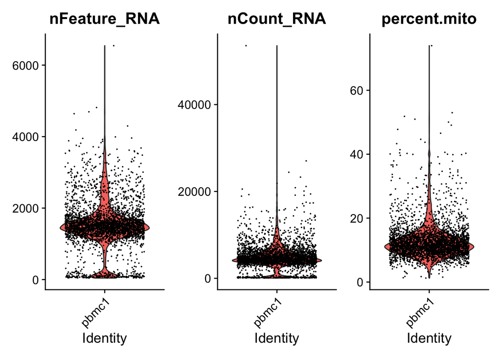

```r
#### Calculate the percentage of mitochondrial genes
pbmc_10x_v3[["percent.mito"]] <- PercentageFeatureSet(pbmc_10x_v3, pattern = "^MT-")
pbmc_10x_v3$percent.mito <- as.numeric(pbmc_10x_v3$percent.mito)

#### Visualize the QC metrics with violin plots
VlnPlot(pbmc_10x_v3, features = c("nFeature_RNA", "nCount_RNA", "percent.mito"), ncol = 3)
```

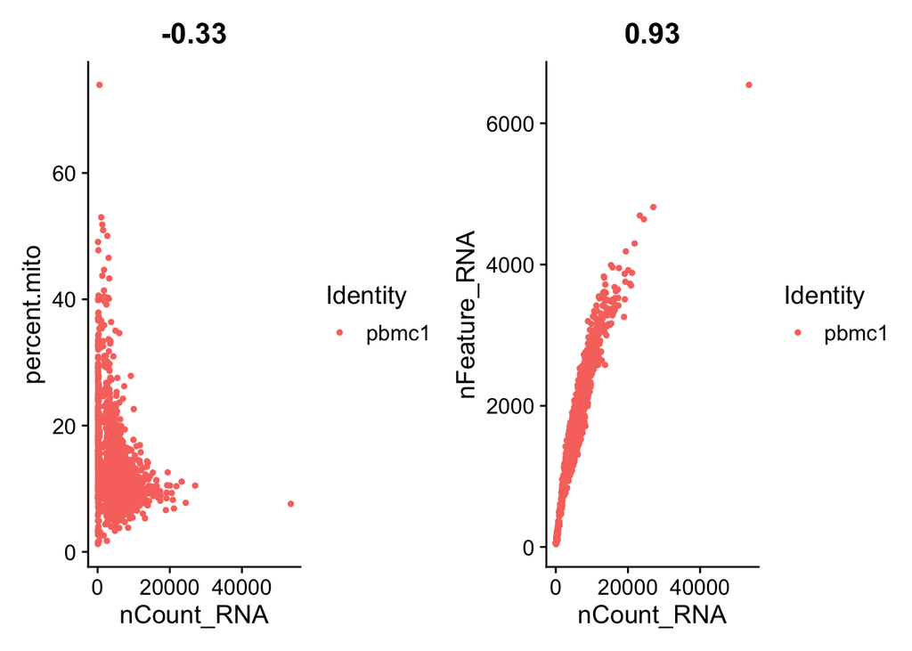

```r
#### Step 2: Examine relationships between QC metrics using scatter plots
FeatureScatter(pbmc_10x_v3, feature1 = "nCount_RNA", feature2 = "percent.mito") +
  FeatureScatter(pbmc_10x_v3, feature1 = "nCount_RNA", feature2 = "nFeature_RNA")
```

```r
class(pbmc_10x_v3$percent.mito)
```

```
## [1] "numeric"
```

```r
class(pbmc_10x_v3$nFeature_RNA)
```

```
## [1] "integer"
```

```r
class(pbmc_10x_v3$nCount_RNA)
```

```
## [1] "numeric"
```